# Public perceptions of multiple risks during the COVID-19 pandemic in Italy and Sweden. Reproducing original findings and extending it with data for Poland.

Mateusz Baryła, Konrad Lewszyk

May 26, 2022

# Agenda

1. Searching for the right study
2. The original study
3. Survey replication
4. Extended study
5. Original data
6. Gathered data
7. Steps to preprocess
8. Functions and good practice coding
9. Full reproducibility
10. Results

# Searching for the study

What we looked for in our target study:  
1. Available data with labeled and coherent variables  
2. Available survey process  
3. Available codes  
4. A realistic reproducible approach

# Original Study

[figure not shown]

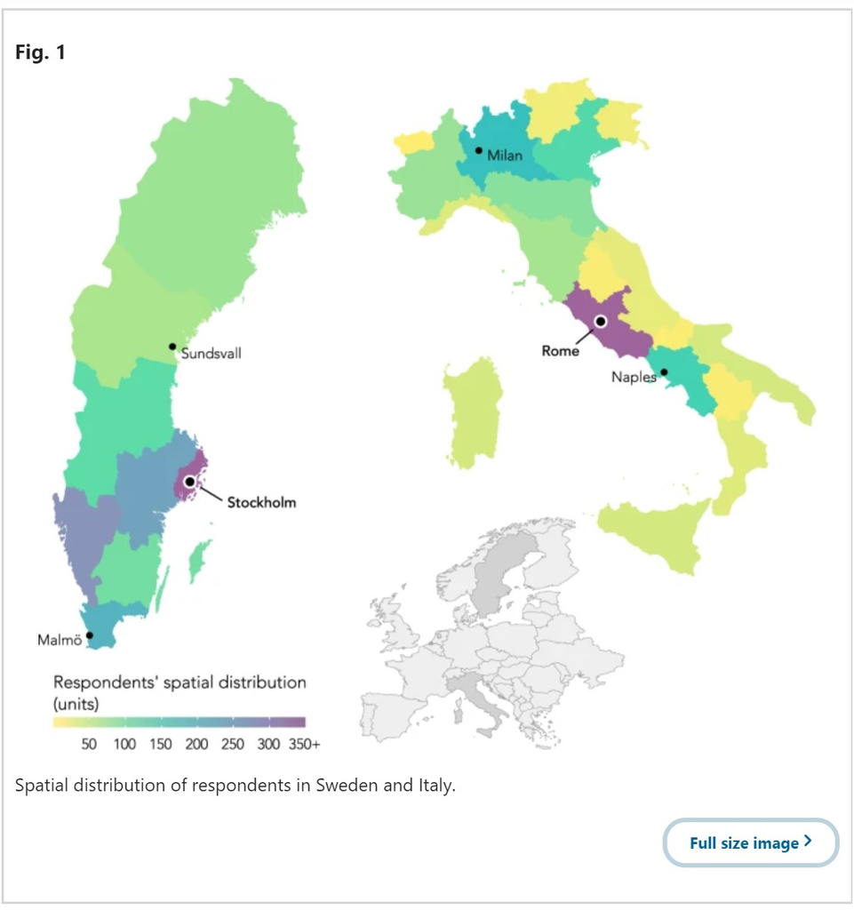

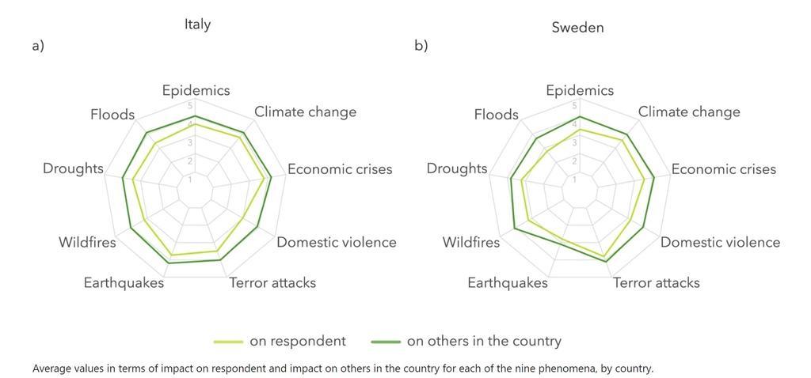

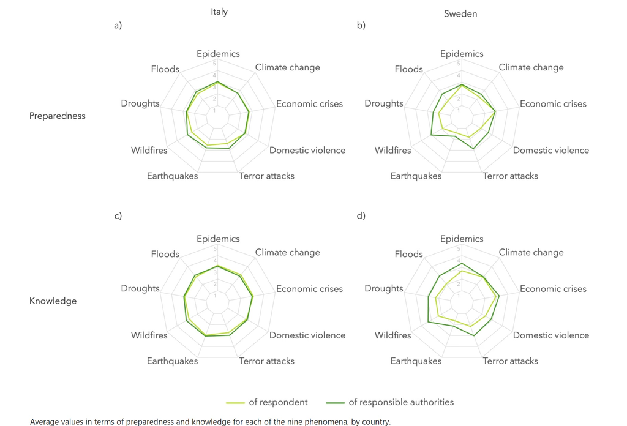

# Survey replication

Link to our survey: https://docs.google.com/forms/d/e/1FAIpQLSeN__k2KDdbRZIkhZ3ubUIVTXc6kPAtjSIqh1bI07bDzVrpNg/viewform?fbclid=IwAR26g8tf0azKeNHSU1FgNR1wvvhTrOis891X9dU9bBNVU1gdfoan9cZkcVE

# Extended study

We extended the study by collecting data from Polish respondents and we managed to get a little over 20 respondents to participate. As the sample we collected was rather small, there was no point in extending the study by Poland’s regional analysis. Therefore we focued on the radar graphs and the perceptions of risk by country.

It is crucial to mention that the study was conducted during the onset of the pandemic in 2020. Our extension of the study was done after the vaccination period and towards the end of the pandemic. This means that our respondents could perceive risk differently than they do now, and the time factor impacts our study.

# Original data

| INTNR | gender | age | MUN_ITA | NUTS2 | V9_1 | V9_2 | V9_3 | V9_4 | V9_5 | V9_6 | V9_7 | V9_8 | V9_9 | V19_1 | V19_2 | V19_3 | V19_4 | V19_5 | V19_6 | V19_7 | V19_8 | V19_9 | V29_1 | V29_2 | V29_3 | V29_4 | V29_5 | V29_6 | V29_7 | … |
| --- | --- | --- | --- | --- | --- | --- | --- | --- | --- | --- | --- | --- | --- | --- | --- | --- | --- | --- | --- | --- | --- | --- | --- | --- | --- | --- | --- | --- | --- | --- |
| 400 | 2 | 56 | 16 | NA | 3 | 4 | 4 | 3 | 4 | 4 | 3 | 3 | 4 | 4 | 4 | 4 | 3 | 4 | 4 | 5 | 4 | 3 | 3 | 2 | 4 | 4 | 5 | 4 | 5 | … |
| 688 | 1 | 42 | 19 | NA | 4 | 4 | 4 | 3 | 2 | 1 | 3 | 2 | 4 | 2 | 4 | 3 | 2 | 3 | 2 | 4 | 5 | 2 | 5 | 5 | 3 | 2 | 3 | 5 | 3 | … |
| 1237 | 1 | 57 | 19 | NA | 1 | 1 | 1 | 2 | 4 | 2 | 1 | 4 | 4 | 3 | 2 | 4 | 3 | 5 | 4 | 4 | 5 | 4 | 3 | 3 | 3 | 3 | 2 | 3 | 4 | … |
| 989 | 2 | 50 | 16 | NA | 3 | 2 | 2 | 3 | 4 | 2 | 1 | 5 | 5 | 4 | 5 | 5 | 5 | 5 | 5 | 5 | 5 | 5 | 4 | 5 | 5 | 5 | 5 | 5 | 5 | … |
| 1078 | 1 | 30 | 15 | NA | 3 | 3 | 3 | 3 | 3 | 3 | 3 | 3 | 3 | 3 | 3 | 3 | 3 | 3 | 3 | 3 | 3 | 3 | 3 | 3 | 3 | 3 | 3 | 3 | 3 | … |
| 1522 | 1 | 38 | 15 | NA | 3 | 1 | 1 | 3 | 4 | 3 | 1 | 3 | 3 | 3 | 4 | 3 | 5 | 5 | 3 | 1 | 4 | 3 | 2 | 3 | 3 | 3 | 3 | 3 | 3 | … |

# Gathered data

| Timestamp | X1..How.likely.do.you.think.it.is.that.you.are.directly.involved.in.the.following.phenomena…Epidemics. | X1..How.likely.do.you.think.it.is.that.you.are.directly.involved.in.the.following.phenomena…Floods. | X1..How.likely.do.you.think.it.is.that.you.are.directly.involved.in.the.following.phenomena…Droughts. | X1..How.likely.do.you.think.it.is.that.you.are.directly.involved.in.the.following.phenomena…Wildfires. | X1..How.likely.do.you.think.it.is.that.you.are.directly.involved.in.the.following.phenomena…Earthquakes. | X1..How.likely.do.you.think.it.is.that.you.are.directly.involved.in.the.following.phenomena…Terror.attacks. | X1..How.likely.do.you.think.it.is.that.you.are.directly.involved.in.the.following.phenomena…Domestic.violence. | X1..How.likely.do.you.think.it.is.that.you.are.directly.involved.in.the.following.phenomena…Economic.crises. | X1..How.likely.do.you.think.it.is.that.you.are.directly.involved.in.the.following.phenomena…Climate.change. | X2..In.case.you.are.directly.involved..how.much.damage.do.you.think.the.following.phenomena.can.cause.to.you…Epidemics. | X2..In.case.you.are.directly.involved..how.much.damage.do.you.think.the.following.phenomena.can.cause.to.you…Floods. | X2..In.case.you.are.directly.involved..how.much.damage.do.you.think.the.following.phenomena.can.cause.to.you…Droughts. | X2..In.case.you.are.directly.involved..how.much.damage.do.you.think.the.following.phenomena.can.cause.to.you…Wildfires. | X2..In.case.you.are.directly.involved..how.much.damage.do.you.think.the.following.phenomena.can.cause.to.you…Earthquakes. | X2..In.case.you.are.directly.involved..how.much.damage.do.you.think.the.following.phenomena.can.cause.to.you…Terror.attacks. | X2..In.case.you.are.directly.involved..how.much.damage.do.you.think.the.following.phenomena.can.cause.to.you…Domestic.violence. | X2..In.case.you.are.directly.involved..how.much.damage.do.you.think.the.following.phenomena.can.cause.to.you…Economic.crises. | X2..In.case.you.are.directly.involved..how.much.damage.do.you.think.the.following.phenomena.can.cause.to.you…Climate.change. | X3..In.case.they.occur.in.Poland..how.much.damage.do.you.think.the.following.phenomena.can.cause.to.others.living.in.Poland…Epidemics. | X3..In.case.they.occur.in.Poland..how.much.damage.do.you.think.the.following.phenomena.can.cause.to.others.living.in.Poland…Floods. | X3..In.case.they.occur.in.Poland..how.much.damage.do.you.think.the.following.phenomena.can.cause.to.others.living.in.Poland…Droughts. | X3..In.case.they.occur.in.Poland..how.much.damage.do.you.think.the.following.phenomena.can.cause.to.others.living.in.Poland…Wildfires. | X3..In.case.they.occur.in.Poland..how.much.damage.do.you.think.the.following.phenomena.can.cause.to.others.living.in.Poland…Earthquakes. | X3..In.case.they.occur.in.Poland..how.much.damage.do.you.think.the.following.phenomena.can.cause.to.others.living.in.Poland…Terror.attacks. | X3..In.case.they.occur.in.Poland..how.much.damage.do.you.think.the.following.phenomena.can.cause.to.others.living.in.Poland…Domestic.violence. | X3..In.case.they.occur.in.Poland..how.much.damage.do.you.think.the.following.phenomena.can.cause.to.others.living.in.Poland…Economic.crises. | X3..In.case.they.occur.in.Poland..how.much.damage.do.you.think.the.following.phenomena.can.cause.to.others.living.in.Poland…Climate.change. | X4..How.prepared.do.you.think.the.responsible.authorities.in.Poland.are.to.face.the.following.phenomena…Epidemics. | X4..How.prepared.do.you.think.the.responsible.authorities.in.Poland.are.to.face.the.following.phenomena…Floods. | … |
| --- | --- | --- | --- | --- | --- | --- | --- | --- | --- | --- | --- | --- | --- | --- | --- | --- | --- | --- | --- | --- | --- | --- | --- | --- | --- | --- | --- | --- | --- | --- |
| 2022/05/14 6:33:48 PM GMT+2 | 5 Very likely | 5 Very likely | 4 | 4 | 4 | 4 | 5 Very likely | 5 Very likely | 5 Very likely | 5. Severe damage | 5. Severe damage | 4 | 3 | 2 | 3 | 4 | 5. Severe damage | 4 | 5. Severe damage | 5. Severe damage | 4 | 5. Severe damage | 4 | 4 | 5. Severe damage | 4 | 4 | 5. Highly prepared | 5. Highly prepared | … |
| 2022/05/18 4:13:26 PM GMT+2 | 5 Very likely | 3 | 2 | 1. Not likely at all | 1. Not likely at all | 5 Very likely | 3 | 5 Very likely | 4 | 5. Severe damage | 3 | 3 | 2 | 1. No damage | 5. Severe damage | 5. Severe damage | 5. Severe damage | 5. Severe damage | 4 | 4 | 3 | 4 | 4 | 2 | 2 | 5. Severe damage | 5. Severe damage | 4 | 2 | … |
| 2022/05/18 5:37:35 PM GMT+2 | 4 | 1. Not likely at all | 3 | 1. Not likely at all | 1. Not likely at all | 1. Not likely at all | 1. Not likely at all | 1. Not likely at all | 2 | 3 | I don’t know | 2 | I don’t know | I don’t know | I don’t know | I don’t know | I don’t know | 3 | 3 | 3 | 2 | 1. No damage | 1. No damage | 2 | 3 | 4 | 3 | 3 | 2 | … |

# Steps to preprocess

[interactive chart not shown]

# Functions and good practice coding

In order to follow the teachings of the Reproducible Research class, we wrote the following functions to automate our graphing process:  
1. derive_necessary_columns  
2. aggregate_method  
3. derive_dataframe_for_country  
4. graph_radar

# Full reproducibility

1. Groundhog library for reproducible environment
2. GitHub for working on code (we created issue and PR, as well as merge to master branch)
3. Google Drive for storing data (we know that storing data on public repository is not a good practice)

# Results

## Damage

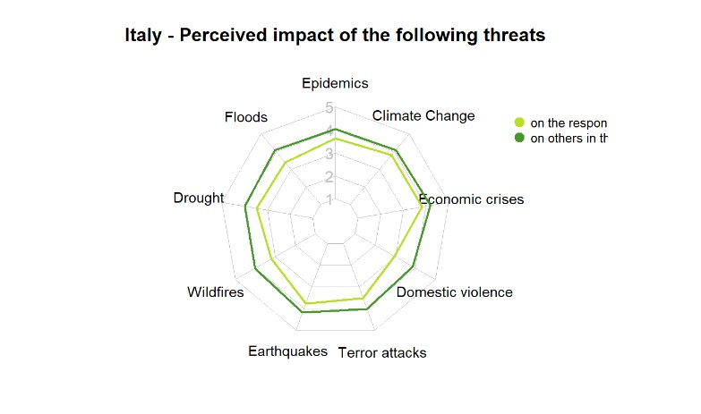

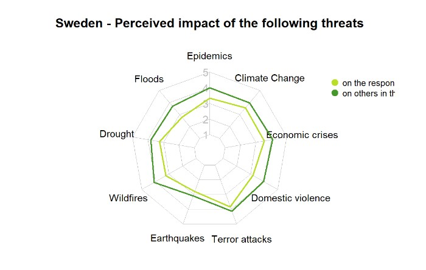

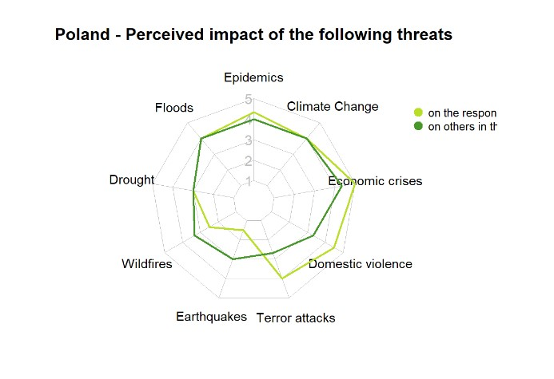

## Preparedness

[figure not shown]

[figure not shown]

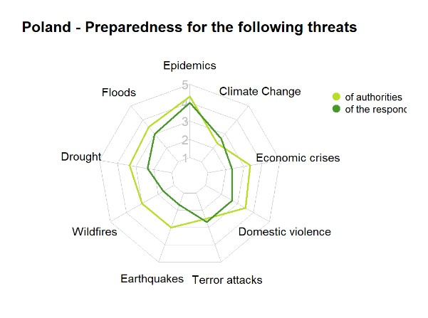

## Knowledge

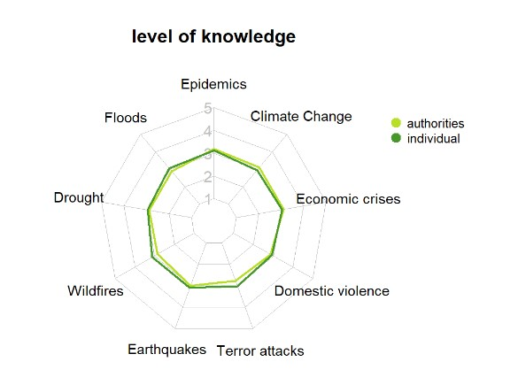

[figure not shown]

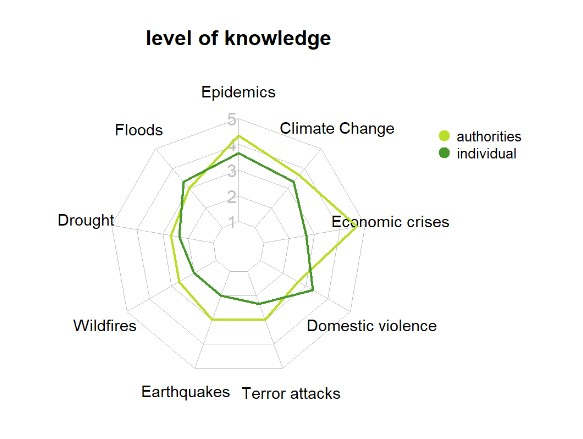

# Sources

Original study: https://www.nature.com/articles/s41597-020-00778-7?fbclid=IwAR1GqAQNW6oCa3gQLC9JEpVaJBAw8SBcc7fobxNX5ybJzwzZvirVxixXVlY